# Analyzing Individual BGG Users

Phil Henrickson

2021-12-01

Load previously queried training and test data from the local layer.

Set function for displaying probabilities

Fit models and analyze collection for **Texjets281**.

## Games in Collection

How many games has the user owned/played in the training set (games prior to 2020)?

```
## # A tibble: 1 × 3
##   username   games_owned games_played
##   <chr>            <dbl>        <dbl>
## 1 Texjets281         157          580
```

## Coefficients for Texjets281

Examine coefficients from the trained model.

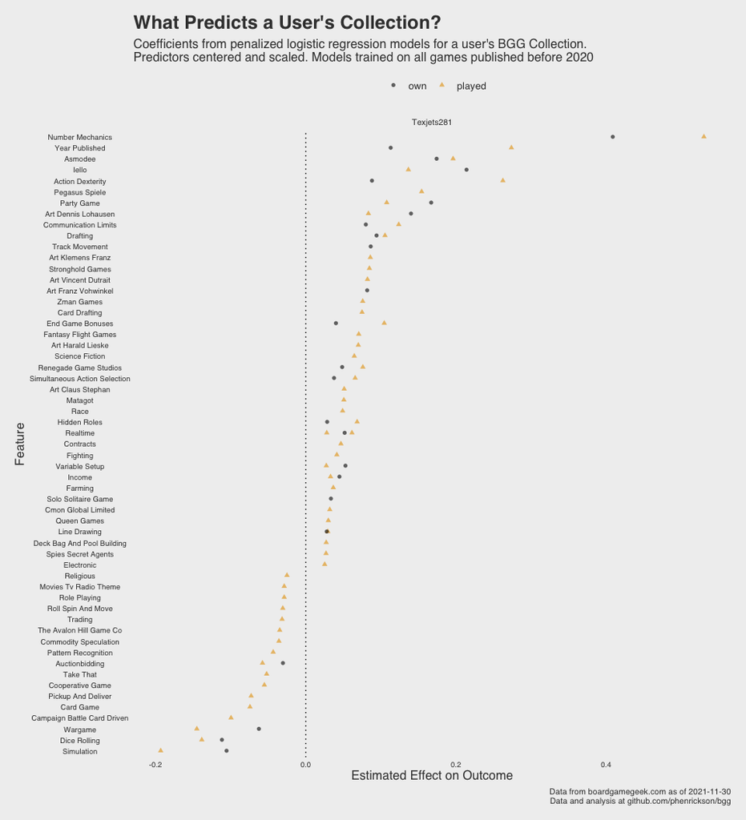

## Assessment

Examine separation plot for training set (cross validated predictions).

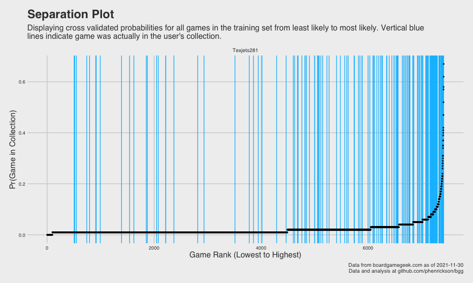

Formally assess how well the model did in resampling.

| outcome_type | .metric | .estimator | .estimate |
| --- | --- | --- | --- |
| own | roc_auc | binary | 0.802 |
| played | roc_auc | binary | 0.820 |

## Predicted Games in Collection from Training

Examine top games from resampling.

Top Overall Games for User from Resampling

| username | yearpublished | game_id | name | pred_played | pred_own | actual_played | actual_own |
| --- | --- | --- | --- | --- | --- | --- | --- |
| Texjets281 | 2018 | 205896 | Rising Sun | 0.96 | 0.67 | 1 | 0 |
| Texjets281 | 2017 | 174430 | Gloomhaven | 0.95 | 0.62 | 1 | 1 |
| Texjets281 | 2019 | 283863 | The Magnificent | 0.96 | 0.58 | 1 | 0 |
| Texjets281 | 2019 | 276025 | Maracaibo | 0.84 | 0.57 | 1 | 1 |
| Texjets281 | 2017 | 220308 | Gaia Project | 0.91 | 0.52 | 1 | 1 |
| Texjets281 | 2012 | 120677 | Terra Mystica | 0.86 | 0.47 | 1 | 0 |
| Texjets281 | 2015 | 171273 | FUSE | 0.83 | 0.42 | 1 | 0 |
| Texjets281 | 2007 | 31481 | Galaxy Trucker | 0.54 | 0.41 | 1 | 1 |
| Texjets281 | 2014 | 156129 | Deception: Murder in Hong Kong | 0.91 | 0.40 | 1 | 1 |
| Texjets281 | 2014 | 146886 | La Granja | 0.90 | 0.39 | 1 | 0 |
| Texjets281 | 2019 | 257066 | Sierra West | 0.66 | 0.37 | 0 | 0 |
| Texjets281 | 2008 | 38453 | Space Alert | 0.70 | 0.37 | 1 | 1 |
| Texjets281 | 2019 | 281259 | The Isle of Cats | 0.68 | 0.35 | 0 | 0 |
| Texjets281 | 2015 | 171623 | The Voyages of Marco Polo | 0.64 | 0.35 | 1 | 0 |
| Texjets281 | 2016 | 198773 | Codenames: Pictures | 0.70 | 0.34 | 0 | 0 |
| Texjets281 | 2010 | 82702 | Funfair | 0.73 | 0.31 | 0 | 0 |
| Texjets281 | 2012 | 123096 | Space Cadets | 0.94 | 0.31 | 1 | 0 |
| Texjets281 | 2015 | 178900 | Codenames | 0.54 | 0.30 | 1 | 0 |
| Texjets281 | 2018 | 245643 | Luxor | 0.24 | 0.29 | 1 | 0 |
| Texjets281 | 2018 | 225694 | Decrypto | 0.65 | 0.28 | 1 | 1 |
| Texjets281 | 2018 | 246297 | Shadows: Amsterdam | 0.50 | 0.28 | 0 | 0 |
| Texjets281 | 2019 | 270971 | Era: Medieval Age | 0.93 | 0.27 | 0 | 0 |
| Texjets281 | 2013 | 140620 | Lewis & Clark: The Expedition | 0.72 | 0.26 | 1 | 1 |
| Texjets281 | 2018 | 244711 | Newton | 0.97 | 0.24 | 0 | 0 |
| Texjets281 | 2014 | 159675 | Fields of Arle | 0.64 | 0.23 | 0 | 0 |
| Texjets281 | 2017 | 228341 | Pulsar 2849 | 0.51 | 0.23 | 1 | 1 |
| Texjets281 | 2013 | 145203 | Prosperity | 0.36 | 0.23 | 0 | 0 |
| Texjets281 | 2019 | 266507 | Clank!: Legacy – Acquisitions Incorporated | 0.88 | 0.23 | 1 | 1 |
| Texjets281 | 2017 | 220775 | Codenames: Disney – Family Edition | 0.36 | 0.23 | 0 | 0 |
| Texjets281 | 2017 | 184921 | Bunny Kingdom | 0.61 | 0.22 | 1 | 0 |

[output cut: 70 more lines]

### Most and Least Likely Games

What game does the model think Texjets281 is **most likely to own** that is **not** in their collection?

| username | yearpublished | game_id | name | pred_own |
| --- | --- | --- | --- | --- |
| Texjets281 | 2018 | 205896 | Rising Sun | 0.67 |

What game does the model think Texjets281 is **least likely to own** that **is** in their collection?

| username | yearpublished | game_id | name | pred_own |
| --- | --- | --- | --- | --- |
| Texjets281 | 2009 | 55427 | Mr. Jack in New York | 0.01 |

### Top Games by Year

Top 25 games most likely to be owned by the user in each year, highlighting in blue the games that the user has owned/played.

| rank | 2012 | 2013 | 2014 | 2015 | 2016 | 2017 | 2018 | 2019 |
| --- | --- | --- | --- | --- | --- | --- | --- | --- |
| 1 | Terra Mystica | Lewis & Clark: The Expedition | Deception: Murder in Hong Kong | FUSE | Codenames: Pictures | Gloomhaven | Rising Sun | The Magnificent |
| 2 | Space Cadets | Prosperity | La Granja | The Voyages of Marco Polo | Sushi Go Party! | Gaia Project | Luxor | Maracaibo |
| 3 | Keyflower | Room 25 | Fields of Arle | Codenames | Junk Art | Pulsar 2849 | Decrypto | Sierra West |
| 4 | Rumble in the Dungeon | Patchistory | Spyfall | Mysterium | When I Dream | Codenames: Disney – Family Edition | Shadows: Amsterdam | The Isle of Cats |
| 5 | Smash Up | Legacy: The Testament of Duke de Crecy | Camel Up | Blood Rage | The Networks | Bunny Kingdom | Newton | Era: Medieval Age |
| 6 | The Manhattan Project | Tash-Kalar: Arena of Legends | Alchemists | Brick Party | Agricola (Revised Edition) | Codenames: Duet | Teotihuacan: City of Gods | Clank!: Legacy – Acquisitions Incorporated |
| 7 | Robinson Crusoe: Adventures on the Cursed Island | Glass Road | Sheriff of Nottingham | My Village | Loot N Run | Downforce | Everdell | Tapestry |
| 8 | The Resistance: Avalon | Mascarade | Five Tribes | 504 | Tales & Games: The Pied Piper | Smash Up: What Were We Thinking? | Muse: Awakenings | Amul |
| 9 | Archipelago | Concept | Spurs: A Tale in the Old West | The King Is Dead | Exceed Fighting System | Breaking Bad: The Board Game | Crown of Emara | The King's Dilemma |
| 10 | Targi | Impulse | Medieval Academy | Through the Ages: A New Story of Civilization | Inis | This War of Mine: The Board Game | Underwater Cities | Throw Throw Burrito |
| 11 | Escape: The Curse of the Temple | Bomb Squad | Sons of Anarchy: Men of Mayhem | Tiny Epic Galaxies | Great Western Trail | Mountains of Madness | The Grizzled: Armistice Edition | Yukon Airways |
| 12 | Wiz-War (Eighth Edition) | Eight-Minute Empire: Legends | Ultimate Werewolf | Me Want Cookies! | A Feast for Odin | Twilight Imperium: Fourth Edition | Trapwords | Paris: La Cité de la Lumière |
| 13 | Mini Curling Game | Tales & Games: The Three Little Pigs | HINT | Tales & Games: The Grasshopper & the Ant | Codenames: Deep Undercover | Heaven & Ale | Duelosaur Island | Barrage |
| 14 | Pick-a-Dog | Theseus: The Dark Orbit | Akrotiri | Tales & Games: Little Red Riding Hood | Scythe | Fog of Love | Kero | Carnival of Monsters |
| 15 | Seasons | Sail to India | Imperial Settlers | Queen's Architect | Imhotep | Photosynthesis | Fireball Island: The Curse of Vul-Kar | Paranormal Detectives |
| 16 | Qin | Gravwell: Escape from the 9th Dimension | King of New York | Steampunk Rally | Timebomb | Azul | Hail Hydra | De Vulgari Eloquentia: Deluxe Edition |
| 17 | Yedo | Jungle Speed: Safari | Praetor | Aye, Dark Overlord! The Green Box | Islebound | Harvest Dice | Star Realms: Frontiers | Ninja Academy |
| 18 | Uchronia | Forbidden Desert | Heroes of Normandie | Salem 1692 | Kanagawa | Merlin | The Quacks of Quedlinburg | Aquatica |
| 19 | Il Vecchio | Carcassonne: South Seas | Patchwork | Smash Up: Pretty Pretty Smash Up | Crazy Karts | Secrets | Raids | Last Bastion |
| 20 | Among the Stars | Hanamikoji | Pictopia: Disney Edition | Haleakala | Black Orchestra | LYNGK | Brass: Birmingham | One Key |
| 21 | Dixit Jinx | The Witches: A Discworld Game | Colt Express | Star Realms: Colony Wars | Terraforming Mars | Spirit Island | Pandemic: Fall of Rome | Minecraft: Builders & Biomes |
| 22 | Diavolo | Coal Baron | Star Realms | Runebound (Third Edition) | Tales & Games: Aladdin & the Magic Lamp | Magic Maze | Smash Up: Oops, You Did It Again | Obscurio |
| 23 | Descent: Journeys in the Dark (Second Edition) | Welcome to the Dungeon | Deus | Risk: Europe | Flamme Rouge | Codenames: Marvel | Tudor | MegaCity: Oceania |
| 24 | Libertalia | Ladies & Gentlemen | Helios | Mombasa | Explorers of the North Sea | Muse | First Contact | The Taverns of Tiefenthal |
| 25 | Eight-Minute Empire | A Study in Emerald | Artifacts, Inc. | OctoDice | Beyond Baker Street | Smash Up: Big in Japan | Human Punishment: Social Deduction 2.0 | Black Angel |

### Interactive Table

Interactive table for predictions from resampling.

|  | username | yearpublished | rank | game_id | name | pred_played | pred_own | actual_played | actual_own |
| --- | --- | --- | --- | --- | --- | --- | --- | --- | --- |
| 1 | Texjets281 | 1900 | 1221 | 2785 | Game of Goose | 0.02 | 0.03 | 0 | 0 |
| 2 | Texjets281 | 1900 | 1418 | 2397 | Backgammon | 0 | 0.02 | 0 | 0 |
| 3 | Texjets281 | 1900 | 2461 | 45 | Perudo | 0.01 | 0.02 | 0 | 0 |
| 4 | Texjets281 | 1900 | 2464 | 6424 | Pick Up Sticks | 0.02 | 0.02 | 0 | 0 |
| 5 | Texjets281 | 1900 | 2937 | 5546 | Marbles | 0.02 | 0.01 | 0 | 0 |
| 6 | Texjets281 | 1900 | 2975 | 188 | Go | 0 | 0.01 | 0 | 0 |
| 7 | Texjets281 | 1900 | 3062 | 171 | Chess | 0.01 | 0.01 | 0 | 0 |
| 8 | Texjets281 | 1900 | 3241 | 26952 | International Checkers | 0 | 0.01 | 0 | 0 |
| 9 | Texjets281 | 1900 | 3267 | 1602 | The Royal Game of Ur | 0.01 | 0.01 | 0 | 0 |
| 10 | Texjets281 | 1900 | 3268 | 2083 | Checkers | 0.01 | 0.01 | 0 | 0 |

[output cut: 7403 more lines]

## Predicted Games in Collection 2020 and On

Examine the top games for the test set.

Top Predicted Games for User, 2020 and On

| username | yearpublished | game_id | name | rank | own | played |
| --- | --- | --- | --- | --- | --- | --- |
| Texjets281 | 2020 | 291457 | Gloomhaven: Jaws of the Lion | 1 | 0.51 | 0.88 |
| Texjets281 | 2020 | 184267 | On Mars | 2 | 0.49 | 0.97 |
| Texjets281 | 2020 | 308765 | Praga Caput Regni | 3 | 0.29 | 0.55 |
| Texjets281 | 2020 | 256317 | Guild Master | 4 | 0.24 | 0.75 |
| Texjets281 | 2020 | 306735 | Under Falling Skies | 5 | 0.20 | 0.48 |
| Texjets281 | 2020 | 292333 | Cowboys II: Cowboys & Indians Edition | 6 | 0.19 | 0.62 |
| Texjets281 | 2020 | 317231 | Monasterium | 7 | 0.17 | 0.39 |
| Texjets281 | 2020 | 293275 | Flyin' Goblin | 8 | 0.16 | 0.49 |
| Texjets281 | 2020 | 300322 | Hallertau | 9 | 0.16 | 0.88 |
| Texjets281 | 2020 | 313698 | Monster Expedition | 10 | 0.16 | 0.51 |
| Texjets281 | 2020 | 245658 | Unicorn Fever | 11 | 0.15 | 0.40 |
| Texjets281 | 2020 | 301767 | Mysterium Park | 12 | 0.15 | 0.41 |
| Texjets281 | 2020 | 306040 | Merv: The Heart of the Silk Road | 13 | 0.14 | 0.31 |
| Texjets281 | 2020 | 277927 | Bites | 14 | 0.14 | 0.28 |
| Texjets281 | 2020 | 297030 | Tekhenu: Obelisk of the Sun | 15 | 0.13 | 0.45 |
| Texjets281 | 2020 | 316377 | 7 Wonders (Second Edition) | 16 | 0.13 | 0.55 |
| Texjets281 | 2020 | 323784 | Ghost Letters | 17 | 0.11 | 0.47 |
| Texjets281 | 2020 | 312484 | Lost Ruins of Arnak | 18 | 0.11 | 0.37 |
| Texjets281 | 2020 | 303669 | Magic Rabbit | 19 | 0.10 | 0.25 |
| Texjets281 | 2020 | 304420 | Bonfire | 20 | 0.10 | 0.41 |
| Texjets281 | 2020 | 296151 | Viscounts of the West Kingdom | 21 | 0.10 | 0.58 |
| Texjets281 | 2020 | 319966 | The King Is Dead: Second Edition | 22 | 0.10 | 0.28 |
| Texjets281 | 2020 | 253506 | Versailles 1919 | 23 | 0.10 | 0.20 |
| Texjets281 | 2020 | 295486 | My City | 24 | 0.10 | 0.28 |
| Texjets281 | 2020 | 246900 | Eclipse: Second Dawn for the Galaxy | 25 | 0.10 | 0.63 |
| Texjets281 | 2020 | 295646 | Spyfest | 26 | 0.10 | 0.16 |
| Texjets281 | 2020 | 311193 | Anno 1800 | 27 | 0.10 | 0.38 |
| Texjets281 | 2020 | 307844 | Atheneum: Mystic Library | 28 | 0.10 | 0.71 |
| Texjets281 | 2021 | 343905 | Boonlake | 1 | 0.49 | 0.93 |
| Texjets281 | 2021 | 342942 | Ark Nova | 2 | 0.47 | 0.80 |

[output cut: 53 more lines]

Interactive table for 2020 and On

|  | username | yearpublished | game_id | name | rank | own | played |
| --- | --- | --- | --- | --- | --- | --- | --- |
| 1 | Texjets281 | 2020 | 291457 | Gloomhaven: Jaws of the Lion | 1 | 0.51 | 0.88 |
| 2 | Texjets281 | 2020 | 184267 | On Mars | 2 | 0.49 | 0.97 |
| 3 | Texjets281 | 2021 | 343905 | Boonlake | 3 | 0.49 | 0.93 |
| 4 | Texjets281 | 2021 | 342942 | Ark Nova | 4 | 0.47 | 0.8 |
| 5 | Texjets281 | 2021 | 336794 | Galaxy Trucker | 5 | 0.47 | 0.72 |
| 6 | Texjets281 | 2020 | 308765 | Praga Caput Regni | 6 | 0.29 | 0.55 |
| 7 | Texjets281 | 2021 | 310873 | Carnegie | 7 | 0.29 | 0.89 |
| 8 | Texjets281 | 2022 | 295770 | Frosthaven | 8 | 0.29 | 0.74 |
| 9 | Texjets281 | 2022 | 317511 | Tindaya | 9 | 0.28 | 0.69 |
| 10 | Texjets281 | 2021 | 298102 | Roll Camera!: The Filmmaking Board Game | 10 | 0.26 | 0.77 |

[output cut: 1566 more lines]